# Analyze cyclist stats

Rebin Karaparambil

2025-06-19

```r
library(tidyverse)
```

```r
library(rstudioapi)
library(dplyr)
library(ggplot2)
```

## Cyclistic Bike-Share Analysis (May 2024 – April 2025)

This notebook presents an exploratory data analysis of a year’s worth of bike-share usage data provided by Divvy. The goal is to understand the usage patterns between casual and subscribed memebers to improve strategic decision making and companies profitability.

### Dataset

The data set from the cyclist is available at the [link](https://divvy-tripdata.s3.amazonaws.com/index.html). In this project we analyse the data from May 2024 to April 2025. The datasets should be downloaded and the corresponding CSV files should be available in the folder named “csv_data” to proceed.

```r
script_path <- rstudioapi::getActiveDocumentContext()$path
setwd(dirname(script_path))
```

Read the csv files in to separate data frames:

```r
files <- list.files("csv_data", pattern = "\\.csv$", full.names = TRUE)
for (i in seq_along(files)) {
  df_name <- paste0("df_", i)
  assign(df_name, readr::read_csv(files[i], show_col_types = FALSE))
}
```

### Check datasets and combine

```r
head(df_1)
```

```
## # A tibble: 6 × 13
##   ride_id          rideable_type started_at          ended_at
##   <chr>            <chr>         <dttm>              <dttm>
## 1 7D9F0CE9EC2A1297 classic_bike  2024-05-25 15:52:42 2024-05-25 16:11:50
## 2 02EC47687411416F classic_bike  2024-05-14 15:11:51 2024-05-14 15:22:00
## 3 101370FB2D3402BE classic_bike  2024-05-30 17:46:04 2024-05-30 18:09:16
## 4 E97E396331ED6913 electric_bike 2024-05-17 20:21:54 2024-05-17 20:40:32
## 5 674EDE311C543165 classic_bike  2024-05-22 18:52:20 2024-05-22 18:59:04
## 6 2E3EA4C19F0341A6 electric_bike 2024-05-25 19:32:12 2024-05-25 19:36:17
## # ℹ 9 more variables: start_station_name <chr>, start_station_id <chr>,
## #   end_station_name <chr>, end_station_id <chr>, start_lat <dbl>,
## #   start_lng <dbl>, end_lat <dbl>, end_lng <dbl>, member_casual <chr>
```

```r
colnames(df_1)
```

```
##  [1] "ride_id"            "rideable_type"      "started_at"
##  [4] "ended_at"           "start_station_name" "start_station_id"
##  [7] "end_station_name"   "end_station_id"     "start_lat"
## [10] "start_lng"          "end_lat"            "end_lng"
## [13] "member_casual"
```

Check whether column names in all data frames are similar, before we join all into a single data frame.

```r
dfs <- list(df_1, df_2, df_3, df_4, df_5, df_6, df_7, df_8, df_9, df_10, df_11, df_12)

colnames_list <- lapply(dfs, colnames)
all_same <- all(sapply(colnames_list, function(x) identical(x, colnames_list[[1]])))
print(all_same)
```

```
## [1] TRUE
```

Combine all data frames in to a single data frame as folows,

```r
combined_df <- dplyr::bind_rows(dfs)
dplyr::glimpse(combined_df)
```

```
## Rows: 5,735,884
## Columns: 13
## $ ride_id            <chr> "7D9F0CE9EC2A1297", "02EC47687411416F", "101370FB2D…
## $ rideable_type      <chr> "classic_bike", "classic_bike", "classic_bike", "el…
## $ started_at         <dttm> 2024-05-25 15:52:42, 2024-05-14 15:11:51, 2024-05-…
## $ ended_at           <dttm> 2024-05-25 16:11:50, 2024-05-14 15:22:00, 2024-05-…
## $ start_station_name <chr> "Streeter Dr & Grand Ave", "Sheridan Rd & Greenleaf…
## $ start_station_id   <chr> "13022", "KA1504000159", "13022", "13022", "KA15040…
## $ end_station_name   <chr> "Clark St & Elm St", "Sheridan Rd & Loyola Ave", "W…
## $ end_station_id     <chr> "TA1307000039", "RP-009", "TA1309000010", "TA130700…
## $ start_lat          <dbl> 41.89228, 42.01059, 41.89228, 41.89227, 41.90349, 4…
## $ start_lng          <dbl> -87.61204, -87.66241, -87.61204, -87.61195, -87.643…
## $ end_lat            <dbl> 41.90297, 42.00104, 41.87077, 41.93625, 41.90297, 4…
## $ end_lng            <dbl> -87.63128, -87.66120, -87.62573, -87.65266, -87.631…
## $ member_casual      <chr> "casual", "casual", "member", "member", "casual", "…
```

### Data cleaning and preparation

Inspect the new table that has been created-

```r
colnames(combined_df)
```

```
##  [1] "ride_id"            "rideable_type"      "started_at"
##  [4] "ended_at"           "start_station_name" "start_station_id"
##  [7] "end_station_name"   "end_station_id"     "start_lat"
## [10] "start_lng"          "end_lat"            "end_lng"
## [13] "member_casual"
```

```r
nrow(combined_df)
```

```
## [1] 5735884
```

```r
dim(combined_df)
```

```
## [1] 5735884      13
```

```r
head(combined_df)
```

```
## # A tibble: 6 × 13
##   ride_id          rideable_type started_at          ended_at
##   <chr>            <chr>         <dttm>              <dttm>
## 1 7D9F0CE9EC2A1297 classic_bike  2024-05-25 15:52:42 2024-05-25 16:11:50
## 2 02EC47687411416F classic_bike  2024-05-14 15:11:51 2024-05-14 15:22:00
## 3 101370FB2D3402BE classic_bike  2024-05-30 17:46:04 2024-05-30 18:09:16
## 4 E97E396331ED6913 electric_bike 2024-05-17 20:21:54 2024-05-17 20:40:32
## 5 674EDE311C543165 classic_bike  2024-05-22 18:52:20 2024-05-22 18:59:04
## 6 2E3EA4C19F0341A6 electric_bike 2024-05-25 19:32:12 2024-05-25 19:36:17
## # ℹ 9 more variables: start_station_name <chr>, start_station_id <chr>,
## #   end_station_name <chr>, end_station_id <chr>, start_lat <dbl>,
## #   start_lng <dbl>, end_lat <dbl>, end_lng <dbl>, member_casual <chr>
```

```r
summary(combined_df)
```

```
##    ride_id          rideable_type        started_at
##  Length:5735884     Length:5735884     Min.   :2024-05-01 00:00:41.00
##  Class :character   Class :character   1st Qu.:2024-07-05 18:38:09.04
##  Mode  :character   Mode  :character   Median :2024-09-02 13:34:06.16
##                                        Mean   :2024-09-19 10:22:36.22
##                                        3rd Qu.:2024-11-03 17:34:18.18
##                                        Max.   :2025-04-30 23:59:40.23
##
##     ended_at                      start_station_name start_station_id
##  Min.   :2024-05-01 00:05:45.00   Length:5735884     Length:5735884
##  1st Qu.:2024-07-05 19:00:07.31   Class :character   Class :character
##  Median :2024-09-02 13:57:02.82   Mode  :character   Mode  :character
##  Mean   :2024-09-19 10:39:29.59
##  3rd Qu.:2024-11-03 17:48:03.59
##  Max.   :2025-04-30 23:59:57.54
##
##  end_station_name   end_station_id       start_lat       start_lng
##  Length:5735884     Length:5735884     Min.   :41.64   Min.   :-87.91
##  Class :character   Class :character   1st Qu.:41.88   1st Qu.:-87.66
##  Mode  :character   Mode  :character   Median :41.90   Median :-87.64
##                                        Mean   :41.90   Mean   :-87.65
##                                        3rd Qu.:41.93   3rd Qu.:-87.63
##                                        Max.   :42.07   Max.   :-87.52
##
##     end_lat         end_lng        member_casual
##  Min.   :16.06   Min.   :-144.05   Length:5735884
##  1st Qu.:41.88   1st Qu.: -87.66   Class :character
##  Median :41.90   Median : -87.64   Mode  :character
##  Mean   :41.90   Mean   : -87.65
##  3rd Qu.:41.93   3rd Qu.: -87.63
##  Max.   :87.96   Max.   : 152.53
##  NA's   :6399    NA's   :6399
```

Check for distinct classification in member_casual column-

```r
table(combined_df$member_casual)
```

```
##
##  casual  member
## 2112667 3623217
```

There are 2112667 casual users and 3623217 who are subscribed to a membership. Check the start time column, and create separate columns for date, month, and week.

```r
head(combined_df$started_at)
```

```
## [1] "2024-05-25 15:52:42 UTC" "2024-05-14 15:11:51 UTC"
## [3] "2024-05-30 17:46:04 UTC" "2024-05-17 20:21:54 UTC"
## [5] "2024-05-22 18:52:20 UTC" "2024-05-25 19:32:12 UTC"
```

```r
combined_df$date <- as.Date(combined_df$started_at)
combined_df$month <- format(as.Date(combined_df$date), "%m")
combined_df$day<- format(as.Date(combined_df$date), "%d")
combined_df$year <- format(as.Date(combined_df$date), "%Y")
combined_df$weekday <- format(as.Date(combined_df$date), "%A")
colnames(combined_df)
```

```
##  [1] "ride_id"            "rideable_type"      "started_at"
##  [4] "ended_at"           "start_station_name" "start_station_id"
##  [7] "end_station_name"   "end_station_id"     "start_lat"
## [10] "start_lng"          "end_lat"            "end_lng"
## [13] "member_casual"      "date"               "month"
## [16] "day"                "year"               "weekday"
```

Create a new column with the information on trip duration-

```r
combined_df$trip_duration <- difftime(combined_df$ended_at, combined_df$started_at, units = "secs")
colnames(combined_df)
```

```
##  [1] "ride_id"            "rideable_type"      "started_at"
##  [4] "ended_at"           "start_station_name" "start_station_id"
##  [7] "end_station_name"   "end_station_id"     "start_lat"
## [10] "start_lng"          "end_lat"            "end_lng"
## [13] "member_casual"      "date"               "month"
## [16] "day"                "year"               "weekday"
## [19] "trip_duration"
```

```r
class(combined_df$trip_duration)
```

```
## [1] "difftime"
```

```r
units(combined_df$trip_duration)
```

```
## [1] "secs"
```

Convert difftime class to numeric for further analysis-

```r
combined_df$trip_duration <- as.numeric(combined_df$trip_duration, units = "secs")
is.numeric(combined_df$trip_duration)
```

```
## [1] TRUE
```

Check if there are negative ride duration for irrelevant entries (bikes being taken out of docks and checked for quality by Divvy etc.).

```r
sum(combined_df$trip_duration < 0)
```

```
## [1] 119
```

There are 119 entries were the trip duration is less than zero, and we filter out these irrelevant entries and make a new data frame.

```r
combined_cldf <- filter(combined_df, trip_duration >= 0)
sum(combined_cldf$trip_duration < 0)
```

```
## [1] 0
```

```r
sum(combined_cldf$start_station_name == "HQ QR", na.rm = TRUE)
```

```
## [1] 0
```

```r
nrow(combined_cldf)
```

```
## [1] 5735765
```

```r
colnames(combined_cldf)
```

```
##  [1] "ride_id"            "rideable_type"      "started_at"
##  [4] "ended_at"           "start_station_name" "start_station_id"
##  [7] "end_station_name"   "end_station_id"     "start_lat"
## [10] "start_lng"          "end_lat"            "end_lng"
## [13] "member_casual"      "date"               "month"
## [16] "day"                "year"               "weekday"
## [19] "trip_duration"
```

### Perform descriptive analysis, note all timings are in seconds.

```r
summary(combined_cldf$trip_duration)
```

```
##    Min. 1st Qu.  Median    Mean 3rd Qu.    Max.
##     0.0   329.3   577.1  1013.5  1023.5 93595.1
```

The minimum rental duration is zero seconds, while the maximum is 93595 seconds. The average per time usage is 1013 seconds.

```r
aggregate(combined_cldf$trip_duration ~ combined_cldf$member_casual, FUN = mean)
```

```
##   combined_cldf$member_casual combined_cldf$trip_duration
## 1                      casual                   1471.5814
## 2                      member                    746.3235
```

Casual members on an average trip duration is 1471 seconds, where as subscribed members use relatively less with an anverage of 746 seconds.

```r
aggregate(combined_cldf$trip_duration ~ combined_cldf$member_casual, FUN = median)
```

```
##   combined_cldf$member_casual combined_cldf$trip_duration
## 1                      casual                    714.5755
## 2                      member                    516.8160
```

```r
aggregate(combined_cldf$trip_duration ~ combined_cldf$member_casual, FUN = max)
```

```
##   combined_cldf$member_casual combined_cldf$trip_duration
## 1                      casual                    93595.07
## 2                      member                    89998.10
```

```r
aggregate(combined_cldf$trip_duration ~ combined_cldf$member_casual, FUN = min)
```

```
##   combined_cldf$member_casual combined_cldf$trip_duration
## 1                      casual                           0
## 2                      member                           0
```

Median and max usage of casual members is larger than the subscribed members.

Order week days and compare rides-

```r
combined_cldf$weekday <- ordered(combined_cldf$weekday,
  levels = c("Sunday", "Monday", "Tuesday", "Wednesday", "Thursday", "Friday", "Saturday"))
aggregate(combined_cldf$trip_duration ~ combined_cldf$member_casual + combined_cldf$weekday , FUN = mean)
```

```
##    combined_cldf$member_casual combined_cldf$weekday
## 1                       casual                Sunday
## 2                       member                Sunday
## 3                       casual                Monday
## 4                       member                Monday
## 5                       casual               Tuesday
## 6                       member               Tuesday
## 7                       casual             Wednesday
## 8                       member             Wednesday
## 9                       casual              Thursday
## 10                      member              Thursday
## 11                      casual                Friday
## 12                      member                Friday
## 13                      casual              Saturday
## 14                      member              Saturday
##    combined_cldf$trip_duration
## 1                    1719.3787
## 2                     834.3116
## 3                    1406.4002
## 4                     709.3169
## 5                    1239.3245
## 6                     708.0928
## 7                    1303.5738
## 8                     723.0805
## 9                    1291.8455
## 10                    720.2928
## 11                   1451.0252
## 12                    739.9214
## 13                   1653.6128
## 14                    823.7281
```

Groupby rides as a function of member type and weekday in to a dataframe-

```r
summary_df <- combined_cldf %>%
  group_by(member_casual, weekday) %>%
  summarise(total_rides = n(), average_duration = mean(trip_duration)) %>%
  arrange(member_casual, weekday)
```

### Summary and plots

```r
head(summary_df)
```

```
## # A tibble: 6 × 4
## # Groups:   member_casual [1]
##   member_casual weekday   total_rides average_duration
##   <chr>         <ord>           <int>            <dbl>
## 1 casual        Sunday         354296            1719.
## 2 casual        Monday         244523            1406.
## 3 casual        Tuesday        224093            1239.
## 4 casual        Wednesday      266645            1304.
## 5 casual        Thursday       263459            1292.
## 6 casual        Friday         325427            1451.
```

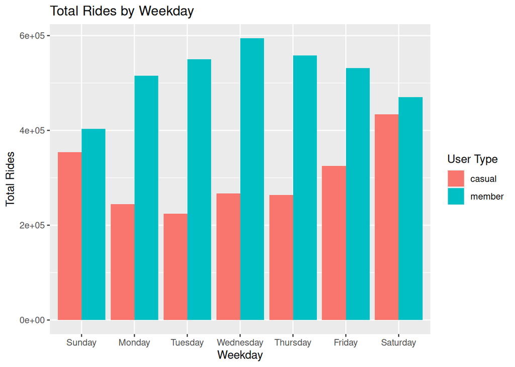

```r
ggplot(summary_df, mapping = aes(x = weekday, y = total_rides, fill = member_casual)) + geom_col(position = "dodge") + labs(title = "Total Rides by Weekday", y = "Total Rides", x = "Weekday", fill = "User Type")
```

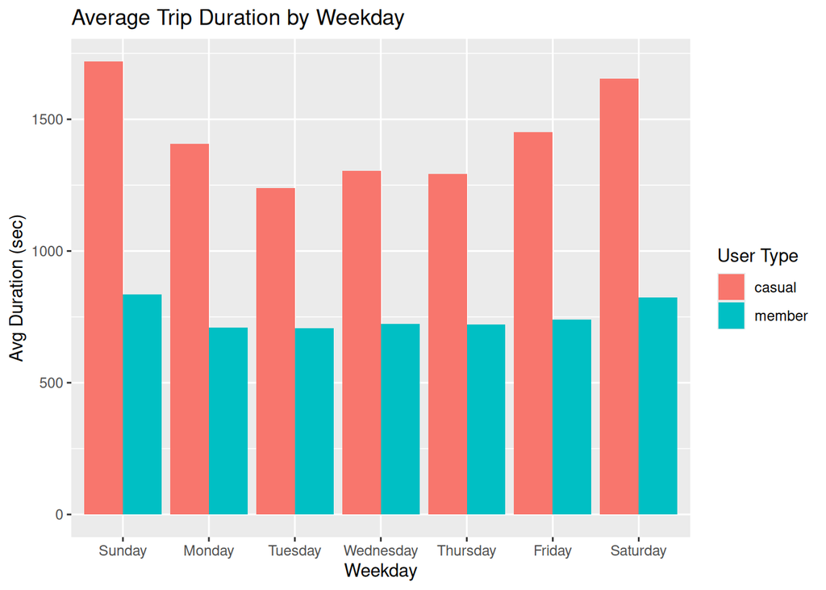

```r
ggplot(summary_df, mapping = aes(x = weekday, y = average_duration, fill = member_casual)) + geom_col(position = "dodge") + labs(title = "Average Trip Duration by Weekday", y = "Avg Duration (sec)", x = "Weekday", fill = "User Type")
```

## Conclusion

Export summary data frame as CSV for further analysis-

```r
write.csv(summary_df, "summary_df.csv", row.names = FALSE)
```